# Functional pi Tau Diagnostics

test_susine

2026-04-16

Summary: Uses the active `test_susine` simulation helpers to generate fixed-tier `susie2_oligogenic` effect vectors `b`, annotation vectors `a`, and normalized-softmax prior inclusion vectors `pi(tau)`. The workbook grids over `annotation_r2` and `inflate_match` so we can see how the `tau` regime changes across annotation quality settings for `p = 1000`.

# 1 Overview

We study the transform

$$\pi_j(\tau) \propto \exp\left(\frac{|a_j| / s(a)}{\tau}\right),$$

where `s(a)` is a robust scale estimate of `|a|`.

In this workbook:

- `b` is simulated with `simulate_effect_sizes_susie2_oligogenic()`;
- `a` is simulated with `simulate_priors()` over a grid of `annotation_r2` and `inflate_match`;
- `pi(tau)` is computed for a log-spaced grid of `tau` values.

The main diagnostics are:

- normalized entropy: `1 = uniform`, `0 = binary`;
- effective support size: `1 / sum(pi^2)`;
- top-k mass;
- largest prior inclusion weight;
- total mass assigned to the true causal set.

# 2 Setup

```r
here::i_am("vignettes/one_off_validations/functional_pi_tau_diagnostics.Rmd")
devtools::load_all(here::here(), quiet = TRUE)

library(dplyr)
library(ggplot2)
library(knitr)
library(purrr)
library(scales)
library(tidyr)
```

# 3 User Options

```r
p <- 1000L
architecture_label <- "susie2_oligogenic"
effect_sd <- 1

# Smoke-size defaults for fast iteration.
annotation_r2_grid <- c(0, 0.5)
inflate_match_grid <- c(0.2, 1.0)

n_beta_draws <- 4L
n_annotations_per_beta <- 2L

# Full grid requested for the main pass:
# annotation_r2_grid <- c(0, 0.2, 0.5)
# inflate_match_grid <- c(0.01, 0.2, 0.5, 0.8, 1.0)
# n_beta_draws <- 20L
# n_annotations_per_beta <- 4L

eta_uniform <- 0
tau_grid <- exp(seq(log(0.01), log(10), length.out = 10))

ess_targets <- c(
  "binary-ish" = 0.01,
  "focused" = 0.05,
  "intermediate" = 0.20,
  "diffuse" = 0.50,
  "uniform-ish" = 0.90
)

reference_regimes <- c("binary-ish", "intermediate", "uniform-ish")
uniform_pi <- 1 / p

cat("architecture =", architecture_label, "\n")
```

```
## architecture = susie2_oligogenic
```

```r
cat("p =", p, "\n")
```

```
## p = 1000
```

```r
cat("uniform pi =", signif(uniform_pi, 3), "\n")
```

```
## uniform pi = 0.001
```

```r
cat("annotation_r2 grid =", paste(annotation_r2_grid, collapse = ", "), "\n")
```

```
## annotation_r2 grid = 0, 0.5
```

```r
cat("inflate_match grid =", paste(inflate_match_grid, collapse = ", "), "\n")
```

```
## inflate_match grid = 0.2, 1
```

```r
cat("beta draws per setting grid =", n_beta_draws, "\n")
```

```
## beta draws per setting grid = 4
```

```r
cat("annotation draws per beta =", n_annotations_per_beta, "\n")
```

```
## annotation draws per beta = 2
```

```r
cat("tau range =", signif(min(tau_grid), 3), "to", signif(max(tau_grid), 3), "\n")
```

```
## tau range = 0.01 to 10
```

# 4 Helpers

```r
fmt_num <- function(x) {
  formatC(x, format = "f", digits = 2)
}

make_setting_label <- function(annotation_r2, inflate_match) {
  paste0("R2=", fmt_num(annotation_r2), " | infl=", fmt_num(inflate_match))
}

robust_abs_scale <- function(annotation, eps = 1e-8) {
  abs_a <- abs(as.numeric(annotation))
  scale_val <- stats::mad(
    abs_a,
    center = stats::median(abs_a),
    constant = 1,
    na.rm = TRUE
  )
  if (!is.finite(scale_val) || scale_val <= eps) {
    scale_val <- stats::sd(abs_a, na.rm = TRUE)
  }
  if (!is.finite(scale_val) || scale_val <= eps) {
    scale_val <- 1
  }
  scale_val
}

softmax_pi_from_annotation <- function(annotation,
                                       tau,
                                       eta = 0,
                                       eps = 1e-8) {
  stopifnot(length(annotation) > 0, is.finite(tau), tau > 0)
  stopifnot(is.finite(eta), eta >= 0, eta < 1)

  scale_val <- robust_abs_scale(annotation, eps = eps)
  score <- abs(as.numeric(annotation)) / (scale_val + eps)
  logits <- score / tau
  logits <- logits - max(logits, na.rm = TRUE)
  weights <- exp(logits)
  weights <- weights / sum(weights)

  if (eta > 0) {
    weights <- (1 - eta) * weights + eta / length(weights)
  }

  list(
    pi = as.numeric(weights),
    score = as.numeric(score),
    scale_val = scale_val
  )
}

compute_pi_diagnostics <- function(pi, causal_idx, p) {
  pi <- as.numeric(pi)
  sorted_pi <- sort(pi, decreasing = TRUE)
  entropy <- -sum(pi * log(pmax(pi, 1e-16)))
  ess <- 1 / sum(pi^2)

  tibble::tibble(
    entropy_norm = entropy / log(p),
    ess = ess,
    ess_frac = ess / p,
    max_pi = max(pi),
    top1_mass = sum(sorted_pi[seq_len(min(1L, p))]),
    top5_mass = sum(sorted_pi[seq_len(min(5L, p))]),
    top10_mass = sum(sorted_pi[seq_len(min(10L, p))]),
    top25_mass = sum(sorted_pi[seq_len(min(25L, p))]),
    top50_mass = sum(sorted_pi[seq_len(min(50L, p))]),
    causal_mass = sum(pi[causal_idx]),
    n_gt_5x_uniform = sum(pi > 5 / p),
    n_gt_10x_uniform = sum(pi > 10 / p)
  )
}

pick_reference_tau <- function(summary_tbl, targets) {
  purrr::imap_dfr(targets, function(target, label) {
    idx <- which.min(abs(summary_tbl$ess_frac_median - target))
    tibble::tibble(
      regime = label,
      target_ess_frac = target,
      tau = summary_tbl$tau[idx],
      ess_frac_median = summary_tbl$ess_frac_median[idx],
      entropy_norm_median = summary_tbl$entropy_norm_median[idx],
      max_pi_median = summary_tbl$max_pi_median[idx],
      top10_mass_median = summary_tbl$top10_mass_median[idx],
      causal_mass_median = summary_tbl$causal_mass_median[idx]
    )
  })
}

simulate_priors_zero_safe <- function(beta,
                                      annotation_r2,
                                      inflate_match,
                                      base_sigma2 = NULL,
                                      effect_sd = NULL,
                                      seed = NULL) {
  if (!is.null(seed) && is.finite(seed)) {
    set.seed(as.integer(seed))
  }

  p <- length(beta)
  causal_idx <- which(beta != 0)
  noncausal_idx <- setdiff(seq_len(p), causal_idx)

  if (is.null(effect_sd) || !is.finite(effect_sd) || effect_sd <= 0) {
    effect_sd <- sqrt(max(stats::var(beta[causal_idx]), stats::var(beta), 1))
  }

  if (is.null(annotation_r2) || is.na(annotation_r2)) annotation_r2 <- 0
  if (is.null(inflate_match) || is.na(inflate_match)) inflate_match <- 0
  annotation_r2 <- pmin(pmax(annotation_r2, 0), 1)
  inflate_match <- max(inflate_match, 0)

  causal_var <- stats::var(beta[causal_idx])
  if (is.na(causal_var) || causal_var == 0) {
    causal_var <- effect_sd^2
  }

  mu_0 <- numeric(p)
  if (length(causal_idx)) {
    causal_beta <- as.numeric(beta[causal_idx])
    causal_mean <- mean(causal_beta)
    causal_centered <- causal_beta - causal_mean
    causal_scale <- sqrt(mean(causal_centered^2))
    if (!is.finite(causal_scale) || causal_scale <= 0) {
      causal_scale <- sqrt(causal_var)
    }

    if (length(causal_idx) == 1L || !is.finite(causal_scale) || causal_scale <= 0) {
      mu_0[causal_idx] <- causal_beta
    } else {
      signal_unit <- causal_centered / causal_scale
      noise_unit <- draw_centered_noise(
        length(causal_idx),
        target_scale = 1,
        orthogonal_to = signal_unit
      )
      causal_annotation_centered <- causal_scale * (
        sqrt(annotation_r2) * signal_unit +
          sqrt(1 - annotation_r2) * noise_unit
      )
      mu_0[causal_idx] <- causal_mean + causal_annotation_centered
    }
  }

  theoretical_causal_mu0_var <- if (length(causal_idx) > 1L) {
    mean((mu_0[causal_idx] - mean(mu_0[causal_idx]))^2)
  } else {
    causal_var
  }

  if (length(noncausal_idx)) {
    if (inflate_match <= 0) {
      mu_0[noncausal_idx] <- 0
    } else {
      noncausal_scale <- sqrt(inflate_match) * sqrt(theoretical_causal_mu0_var)
      mu_0[noncausal_idx] <- draw_centered_noise(
        length(noncausal_idx),
        target_scale = noncausal_scale
      )
    }
  }

  observed_r2 <- NA_real_
  if (length(causal_idx) > 1 && stats::sd(beta[causal_idx]) > 0 && stats::sd(mu_0[causal_idx]) > 0) {
    observed_r2 <- stats::cor(mu_0[causal_idx], beta[causal_idx])^2
  }

  base_sigma2 <- base_sigma2 %||% causal_var
  if (is.na(base_sigma2) || base_sigma2 <= 0) {
    base_sigma2 <- effect_sd^2
  }

  sigma_0_2 <- rep(base_sigma2, p)

  list(
    mu_0 = mu_0,
    sigma_0_2 = sigma_0_2,
    observed_r2 = observed_r2
  )
}

plot_metric_facet <- function(summary_tbl,
                              y_med,
                              y_lo,
                              y_hi,
                              title,
                              y_label,
                              percent_y = TRUE) {
  p <- ggplot(summary_tbl, aes(x = .data$tau))
  p <- p +
    geom_ribbon(aes(ymin = {{ y_lo }}, ymax = {{ y_hi }}), fill = "#9ecae1", alpha = 0.35) +
    geom_line(aes(y = {{ y_med }}), color = "#08519c", linewidth = 0.8) +
    scale_x_log10() +
    facet_grid(.data$inflate_match_f ~ .data$annotation_r2_f) +
    labs(
      title = title,
      subtitle = "Columns: annotation_r2, rows: inflate_match",
      x = "tau (log scale)",
      y = y_label
    ) +
    theme_minimal(base_size = 11)

  if (percent_y) {
    p <- p + scale_y_continuous(labels = scales::percent_format(accuracy = 1))
  }

  p
}
```

# 5 Simulate b

This workbook now matches the fixed-tier `susie2_oligogenic` architecture rather than the generic `oligogenic` helper. That means there is no `p_star` knob here: every effect draw has exactly 3 sparse, 5 oligogenic, and 15 polygenic causal variants.

```r
beta_tbl <- tibble::tibble(
  beta_id = seq_len(n_beta_draws),
  beta_seed = 10000L + seq_len(n_beta_draws)
) %>%
  dplyr::mutate(
    effects = purrr::map(
      .data$beta_seed,
      ~ simulate_effect_sizes_susie2_oligogenic(
        p = p,
        seed = .x
      )
    ),
    beta = purrr::map(.data$effects, "beta"),
    causal_idx = purrr::map(.data$effects, "causal_idx"),
    effect_tier = purrr::map(.data$effects, "effect_tier"),
    n_causal = purrr::map_int(.data$causal_idx, length),
    n_sparse = purrr::map_int(.data$effect_tier, ~ sum(.x == "sparse")),
    n_oligogenic = purrr::map_int(.data$effect_tier, ~ sum(.x == "oligogenic")),
    n_polygenic = purrr::map_int(.data$effect_tier, ~ sum(.x == "polygenic"))
  ) %>%
  dplyr::select(-.data$effects)

beta_tbl %>%
  dplyr::summarise(
    n_beta_draws = dplyr::n(),
    min_n_causal = min(.data$n_causal),
    max_n_causal = max(.data$n_causal),
    sparse_per_draw = first(.data$n_sparse),
    oligogenic_per_draw = first(.data$n_oligogenic),
    polygenic_per_draw = first(.data$n_polygenic)
  ) %>%
  knitr::kable(
    digits = 0,
    caption = "Architecture check: every draw matches the fixed susie2_oligogenic 3/5/15 pattern"
  )
```

Architecture check: every draw matches the fixed susie2_oligogenic 3/5/15 pattern

| n_beta_draws | min_n_causal | max_n_causal | sparse_per_draw | oligogenic_per_draw | polygenic_per_draw |
| --- | --- | --- | --- | --- | --- |
| 4 | 23 | 23 | 3 | 5 | 15 |

# 6 Simulate a over the annotation-quality grid

```r
settings_tbl <- tidyr::expand_grid(
  annotation_r2 = annotation_r2_grid,
  inflate_match = inflate_match_grid
) %>%
  dplyr::arrange(.data$annotation_r2, .data$inflate_match) %>%
  dplyr::mutate(
    setting_id = dplyr::row_number(),
    setting_label = make_setting_label(.data$annotation_r2, .data$inflate_match),
    annotation_r2_f = factor(fmt_num(.data$annotation_r2), levels = fmt_num(annotation_r2_grid)),
    inflate_match_f = factor(fmt_num(.data$inflate_match), levels = fmt_num(inflate_match_grid))
  )

annotation_tbl <- tidyr::expand_grid(
  beta_id = beta_tbl$beta_id,
  setting_id = settings_tbl$setting_id,
  annotation_id = seq_len(n_annotations_per_beta)
) %>%
  dplyr::left_join(beta_tbl, by = "beta_id") %>%
  dplyr::left_join(settings_tbl, by = "setting_id") %>%
  dplyr::mutate(
    annotation_seed = 500000L + .data$beta_id * 1000L + .data$setting_id * 10L + .data$annotation_id,
    priors = purrr::pmap(
      list(.data$beta, .data$annotation_r2, .data$inflate_match, .data$annotation_seed),
      function(beta, annotation_r2, inflate_match, annotation_seed) {
        simulate_priors_zero_safe(
          beta = beta,
          annotation_r2 = annotation_r2,
          inflate_match = inflate_match,
          base_sigma2 = effect_sd^2,
          effect_sd = effect_sd,
          seed = annotation_seed
        )
      }
    ),
    annotation = purrr::map(.data$priors, "mu_0"),
    annotation_r2_observed = purrr::map_dbl(.data$priors, "observed_r2"),
    annotation_scale = purrr::map_dbl(.data$annotation, robust_abs_scale),
    causal_abs_mean = purrr::map2_dbl(
      .data$annotation,
      .data$causal_idx,
      ~ mean(abs(.x[.y]))
    ),
    noncausal_abs_mean = purrr::map2_dbl(
      .data$annotation,
      .data$causal_idx,
      ~ mean(abs(.x[-.y]))
    )
  ) %>%
  dplyr::select(
    .data$beta_id,
    .data$annotation_id,
    .data$setting_id,
    .data$setting_label,
    .data$annotation_r2,
    .data$inflate_match,
    .data$annotation_r2_f,
    .data$inflate_match_f,
    .data$annotation_seed,
    .data$beta,
    .data$annotation,
    .data$causal_idx,
    .data$n_causal,
    .data$annotation_r2_observed,
    .data$annotation_scale,
    .data$causal_abs_mean,
    .data$noncausal_abs_mean
  )
```

```r
annotation_tbl %>%
  dplyr::group_by(.data$annotation_r2, .data$inflate_match) %>%
  dplyr::summarise(
    n_annotations = dplyr::n(),
    observed_r2_mean = mean(.data$annotation_r2_observed, na.rm = TRUE),
    observed_r2_sd = stats::sd(.data$annotation_r2_observed, na.rm = TRUE),
    annotation_scale_mean = mean(.data$annotation_scale),
    causal_abs_mean = mean(.data$causal_abs_mean),
    noncausal_abs_mean = mean(.data$noncausal_abs_mean),
    .groups = "drop"
  ) %>%
  knitr::kable(
    digits = 3,
    caption = "Annotation diagnostics by annotation_r2 x inflate_match"
  )
```

Annotation diagnostics by annotation_r2 x inflate_match

| annotation_r2 | inflate_match | n_annotations | observed_r2_mean | observed_r2_sd | annotation_scale_mean | causal_abs_mean | noncausal_abs_mean |
| --- | --- | --- | --- | --- | --- | --- | --- |
| 0.0 | 0.2 | 8 | 0.0 | 0 | 0.075 | 0.327 | 0.145 |
| 0.0 | 1.0 | 8 | 0.0 | 0 | 0.165 | 0.334 | 0.325 |
| 0.5 | 0.2 | 8 | 0.5 | 0 | 0.073 | 0.327 | 0.145 |
| 0.5 | 1.0 | 8 | 0.5 | 0 | 0.162 | 0.334 | 0.325 |

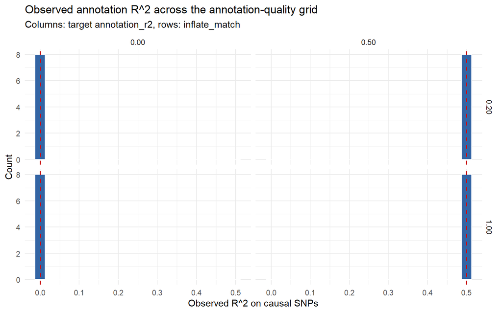

```r
ggplot(annotation_tbl, aes(x = .data$annotation_r2_observed)) +
  geom_histogram(bins = 20, fill = "#3465a4", color = "white") +
  geom_vline(
    aes(xintercept = .data$annotation_r2),
    linetype = "dashed",
    color = "#cc0000",
    linewidth = 0.7,
    inherit.aes = FALSE,
    data = settings_tbl
  ) +
  facet_grid(.data$inflate_match_f ~ .data$annotation_r2_f) +
  labs(
    title = "Observed annotation R^2 across the annotation-quality grid",
    subtitle = "Columns: target annotation_r2, rows: inflate_match",
    x = "Observed R^2 on causal SNPs",
    y = "Count"
  ) +
  theme_minimal(base_size = 11)
```

# 7 Sweep tau

```r
tau_results <- tidyr::expand_grid(
  annotation_row = seq_len(nrow(annotation_tbl)),
  tau = tau_grid
) %>%
  dplyr::mutate(
    annotation = annotation_tbl$annotation[.data$annotation_row],
    causal_idx = annotation_tbl$causal_idx[.data$annotation_row],
    beta_id = annotation_tbl$beta_id[.data$annotation_row],
    annotation_id = annotation_tbl$annotation_id[.data$annotation_row],
    setting_id = annotation_tbl$setting_id[.data$annotation_row],
    setting_label = annotation_tbl$setting_label[.data$annotation_row],
    annotation_r2 = annotation_tbl$annotation_r2[.data$annotation_row],
    inflate_match = annotation_tbl$inflate_match[.data$annotation_row],
    annotation_r2_f = annotation_tbl$annotation_r2_f[.data$annotation_row],
    inflate_match_f = annotation_tbl$inflate_match_f[.data$annotation_row],
    annotation_r2_observed = annotation_tbl$annotation_r2_observed[.data$annotation_row],
    pi_fit = purrr::map2(.data$annotation, .data$tau, ~ softmax_pi_from_annotation(
      annotation = .x,
      tau = .y,
      eta = eta_uniform
    )),
    diagnostics = purrr::map2(.data$pi_fit, .data$causal_idx, ~ compute_pi_diagnostics(
      pi = .x$pi,
      causal_idx = .y,
      p = p
    )),
    score_scale = purrr::map_dbl(.data$pi_fit, "scale_val")
  ) %>%
  tidyr::unnest(.data$diagnostics) %>%
  dplyr::select(
    .data$setting_id,
    .data$setting_label,
    .data$annotation_r2,
    .data$inflate_match,
    .data$annotation_r2_f,
    .data$inflate_match_f,
    .data$beta_id,
    .data$annotation_id,
    .data$annotation_r2_observed,
    .data$tau,
    .data$score_scale,
    .data$entropy_norm,
    .data$ess,
    .data$ess_frac,
    .data$max_pi,
    .data$top1_mass,
    .data$top5_mass,
    .data$top10_mass,
    .data$top25_mass,
    .data$top50_mass,
    .data$causal_mass,
    .data$n_gt_5x_uniform,
    .data$n_gt_10x_uniform
  )

cat("Rows in tau_results:", nrow(tau_results), "\n")
```

```
## Rows in tau_results: 320
```

# 8 Aggregate Diagnostics

```r
summary_by_tau <- tau_results %>%
  dplyr::group_by(
    .data$setting_id,
    .data$setting_label,
    .data$annotation_r2,
    .data$inflate_match,
    .data$annotation_r2_f,
    .data$inflate_match_f,
    .data$tau
  ) %>%
  dplyr::summarise(
    entropy_norm_median = stats::median(.data$entropy_norm),
    entropy_norm_q10 = stats::quantile(.data$entropy_norm, probs = 0.10),
    entropy_norm_q90 = stats::quantile(.data$entropy_norm, probs = 0.90),
    ess_frac_median = stats::median(.data$ess_frac),
    ess_frac_q10 = stats::quantile(.data$ess_frac, probs = 0.10),
    ess_frac_q90 = stats::quantile(.data$ess_frac, probs = 0.90),
    max_pi_median = stats::median(.data$max_pi),
    max_pi_q10 = stats::quantile(.data$max_pi, probs = 0.10),
    max_pi_q90 = stats::quantile(.data$max_pi, probs = 0.90),
    top10_mass_median = stats::median(.data$top10_mass),
    top10_mass_q10 = stats::quantile(.data$top10_mass, probs = 0.10),
    top10_mass_q90 = stats::quantile(.data$top10_mass, probs = 0.90),
    causal_mass_median = stats::median(.data$causal_mass),
    causal_mass_q10 = stats::quantile(.data$causal_mass, probs = 0.10),
    causal_mass_q90 = stats::quantile(.data$causal_mass, probs = 0.90),
    n_gt_10x_uniform_median = stats::median(.data$n_gt_10x_uniform),
    .groups = "drop"
  )

reference_tau_tbl <- summary_by_tau %>%
  dplyr::group_by(
    .data$setting_id,
    .data$setting_label,
    .data$annotation_r2,
    .data$inflate_match,
    .data$annotation_r2_f,
    .data$inflate_match_f
  ) %>%
  dplyr::group_modify(~ pick_reference_tau(.x, ess_targets)) %>%
  dplyr::ungroup()

selected_reference_tau <- reference_tau_tbl %>%
  dplyr::filter(.data$regime %in% reference_regimes)
```

```r
selected_reference_tau %>%
  dplyr::transmute(
    annotation_r2 = .data$annotation_r2,
    inflate_match = .data$inflate_match,
    regime = .data$regime,
    tau = signif(.data$tau, 3),
    ess_frac = percent(.data$ess_frac_median, accuracy = 0.1),
    entropy = percent(.data$entropy_norm_median, accuracy = 0.1),
    max_pi = percent(.data$max_pi_median, accuracy = 0.1),
    top10_mass = percent(.data$top10_mass_median, accuracy = 0.1),
    causal_mass = percent(.data$causal_mass_median, accuracy = 0.1)
  ) %>%
  dplyr::arrange(.data$annotation_r2, .data$inflate_match, .data$regime) %>%
  knitr::kable(
    caption = "Representative tau values by annotation-quality grid point"
  )
```

Representative tau values by annotation-quality grid point

| annotation_r2 | inflate_match | regime | tau | ess_frac | entropy | max_pi | top10_mass | causal_mass |
| --- | --- | --- | --- | --- | --- | --- | --- | --- |
| 0.0 | 0.2 | binary-ish | 1.000 | 0.1% | 11.5% | 86.5% | 96.4% | 93.4% |
| 0.0 | 0.2 | intermediate | 2.150 | 5.5% | 86.0% | 12.8% | 24.1% | 21.1% |
| 0.0 | 0.2 | uniform-ish | 10.000 | 96.7% | 99.8% | 0.3% | 1.9% | 3.1% |
| 0.0 | 1.0 | binary-ish | 0.464 | 0.6% | 34.9% | 27.5% | 88.9% | 0.2% |
| 0.0 | 1.0 | intermediate | 1.000 | 4.9% | 71.5% | 7.6% | 37.5% | 1.7% |
| 0.0 | 1.0 | uniform-ish | 4.640 | 87.6% | 99.1% | 0.3% | 2.8% | 2.3% |
| 0.5 | 0.2 | binary-ish | 1.000 | 0.2% | 14.0% | 78.7% | 96.4% | 95.3% |
| 0.5 | 0.2 | intermediate | 2.150 | 5.7% | 85.7% | 10.8% | 24.9% | 23.1% |
| 0.5 | 0.2 | uniform-ish | 10.000 | 96.5% | 99.8% | 0.3% | 1.9% | 3.1% |
| 0.5 | 1.0 | binary-ish | 0.464 | 0.5% | 34.2% | 34.0% | 85.6% | 0.4% |
| 0.5 | 1.0 | intermediate | 1.000 | 5.9% | 74.9% | 8.0% | 32.1% | 1.9% |
| 0.5 | 1.0 | uniform-ish | 4.640 | 87.8% | 99.1% | 0.3% | 2.7% | 2.3% |

# 9 Main Plots

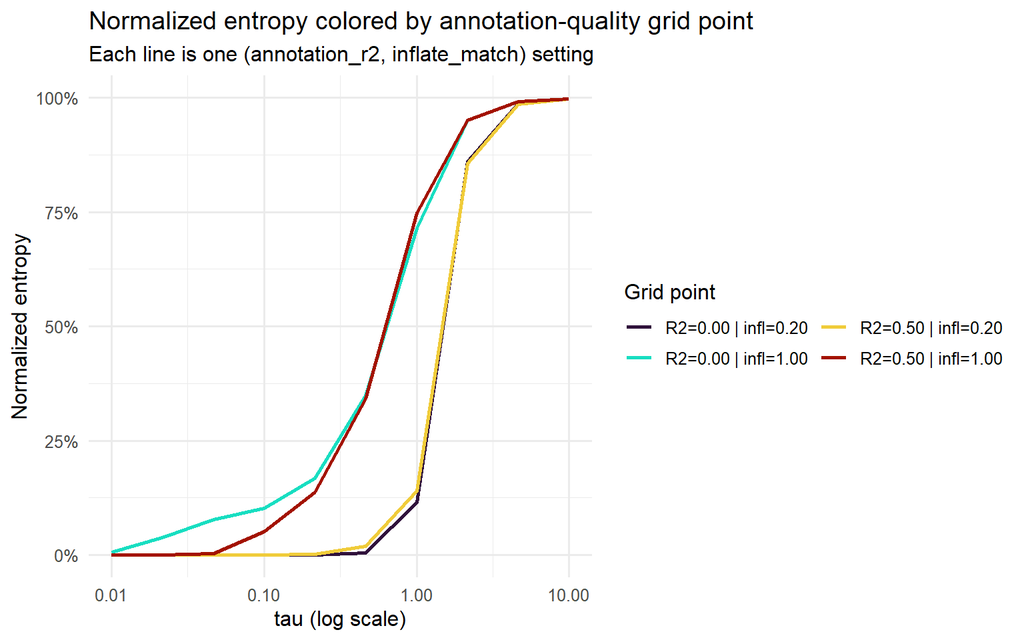

```r
ggplot(
  summary_by_tau,
  aes(
    x = .data$tau,
    y = .data$entropy_norm_median,
    color = .data$setting_label,
    group = .data$setting_label
  )
) +
  geom_line(linewidth = 0.9) +
  scale_x_log10() +
  scale_y_continuous(labels = scales::percent_format(accuracy = 1)) +
  scale_color_viridis_d(option = "turbo", end = 0.95) +
  labs(
    title = "Normalized entropy colored by annotation-quality grid point",
    subtitle = "Each line is one (annotation_r2, inflate_match) setting",
    x = "tau (log scale)",
    y = "Normalized entropy",
    color = "Grid point"
  ) +
  theme_minimal(base_size = 12) +
  guides(color = guide_legend(ncol = 2))
```

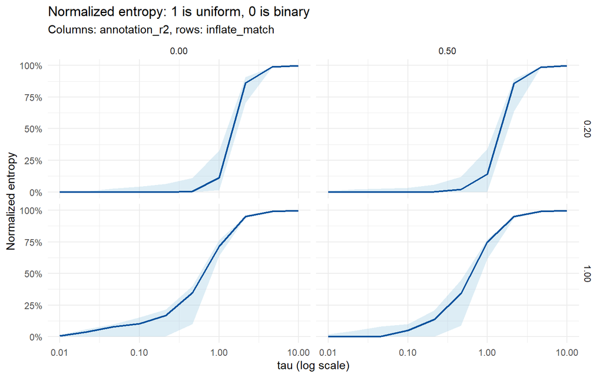

```r
plot_metric_facet(
  summary_by_tau,
  entropy_norm_median,
  entropy_norm_q10,
  entropy_norm_q90,
  title = "Normalized entropy: 1 is uniform, 0 is binary",
  y_label = "Normalized entropy"
)
```

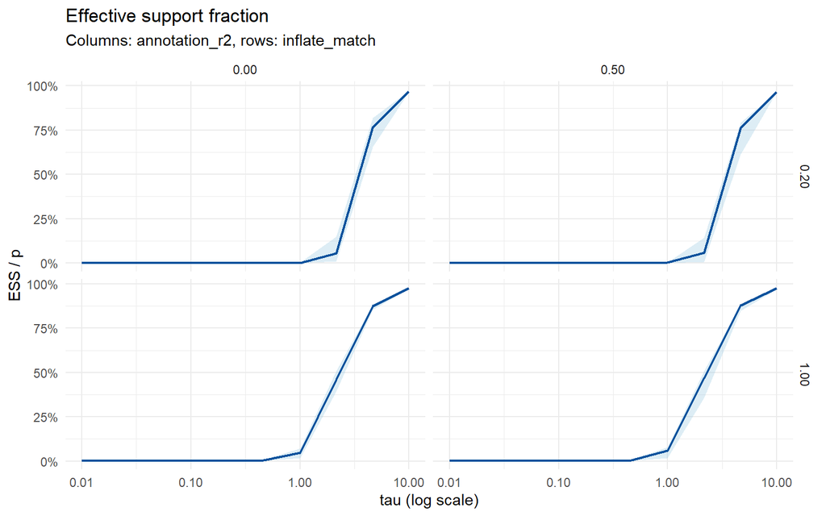

```r
plot_metric_facet(
  summary_by_tau,
  ess_frac_median,
  ess_frac_q10,
  ess_frac_q90,
  title = "Effective support fraction",
  y_label = "ESS / p"
)
```

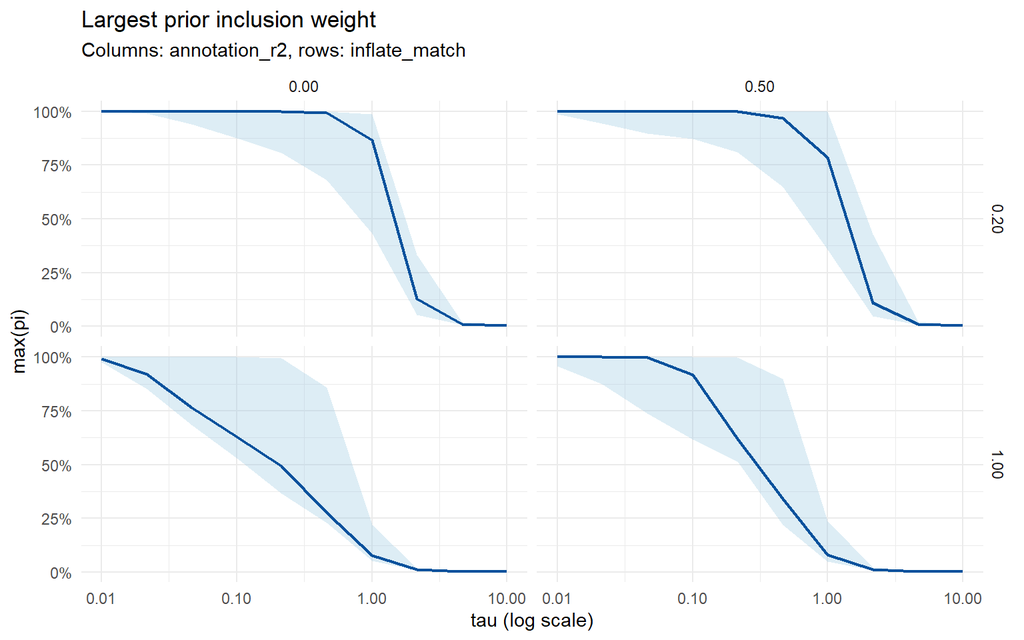

```r
plot_metric_facet(
  summary_by_tau,
  max_pi_median,
  max_pi_q10,
  max_pi_q90,
  title = "Largest prior inclusion weight",
  y_label = "max(pi)"
)
```

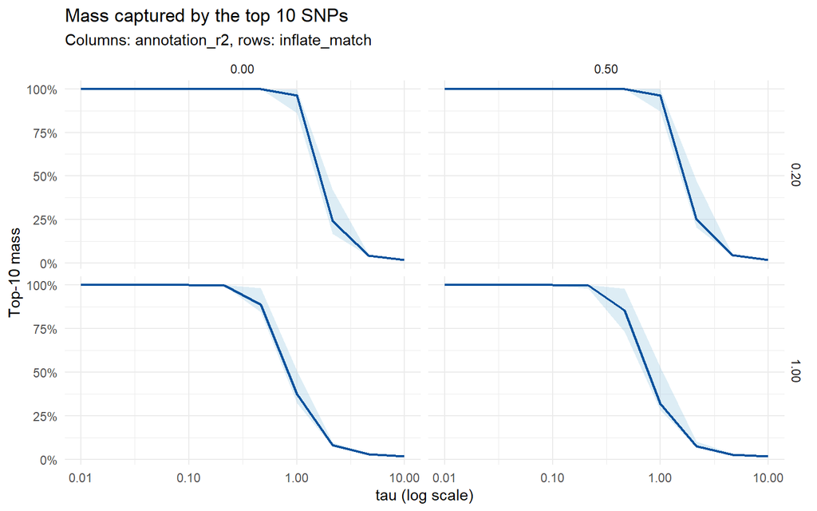

```r
plot_metric_facet(
  summary_by_tau,
  top10_mass_median,
  top10_mass_q10,
  top10_mass_q90,
  title = "Mass captured by the top 10 SNPs",
  y_label = "Top-10 mass"
)
```

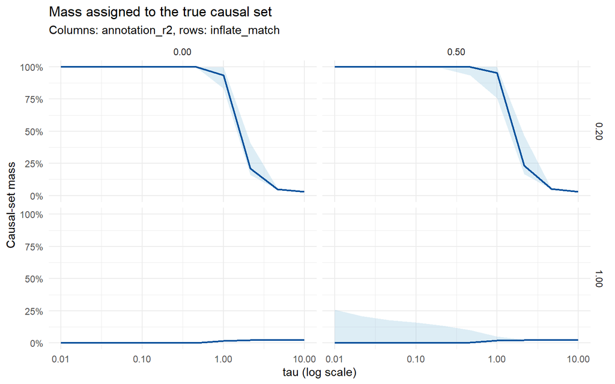

```r
plot_metric_facet(
  summary_by_tau,
  causal_mass_median,
  causal_mass_q10,
  causal_mass_q90,
  title = "Mass assigned to the true causal set",
  y_label = "Causal-set mass"
)
```

# 10 Rank-Mass Curves for Representative Tau Values

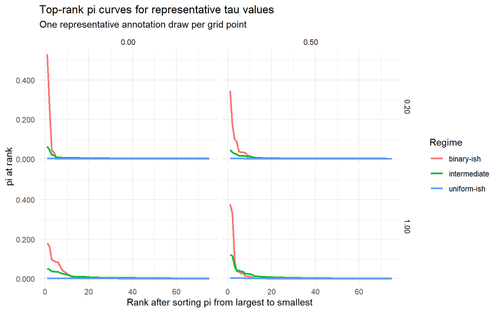

```r
representative_rows <- annotation_tbl %>%
  dplyr::group_by(
    .data$setting_id,
    .data$setting_label,
    .data$annotation_r2,
    .data$inflate_match,
    .data$annotation_r2_f,
    .data$inflate_match_f
  ) %>%
  dplyr::slice(1) %>%
  dplyr::ungroup()

rank_curve_tbl <- selected_reference_tau %>%
  dplyr::left_join(
    representative_rows %>%
      dplyr::select(
        .data$setting_id,
        .data$annotation,
        .data$causal_idx,
        .data$annotation_r2_f,
        .data$inflate_match_f
      ),
    by = c("setting_id", "annotation_r2_f", "inflate_match_f")
  ) %>%
  dplyr::mutate(
    rank_curve = purrr::pmap(
      list(.data$annotation, .data$tau, .data$regime),
      function(annotation, tau, regime) {
        pi_vec <- softmax_pi_from_annotation(
          annotation = annotation,
          tau = tau,
          eta = eta_uniform
        )$pi
        tibble::tibble(
          regime = regime,
          rank = seq_along(pi_vec),
          pi = sort(pi_vec, decreasing = TRUE),
          cumulative_mass = cumsum(sort(pi_vec, decreasing = TRUE))
        )
      }
    )
  ) %>%
  dplyr::select(
    .data$annotation_r2_f,
    .data$inflate_match_f,
    .data$rank_curve
  ) %>%
  tidyr::unnest(.data$rank_curve)

ggplot(
  dplyr::filter(rank_curve_tbl, .data$rank <= 75),
  aes(x = .data$rank, y = .data$pi, color = .data$regime)
) +
  geom_line(linewidth = 0.9) +
  facet_grid(.data$inflate_match_f ~ .data$annotation_r2_f) +
  scale_y_continuous(labels = scales::label_number(accuracy = 0.001)) +
  labs(
    title = "Top-rank pi curves for representative tau values",
    subtitle = "One representative annotation draw per grid point",
    x = "Rank after sorting pi from largest to smallest",
    y = "pi at rank",
    color = "Regime"
  ) +
  theme_minimal(base_size = 11)
```

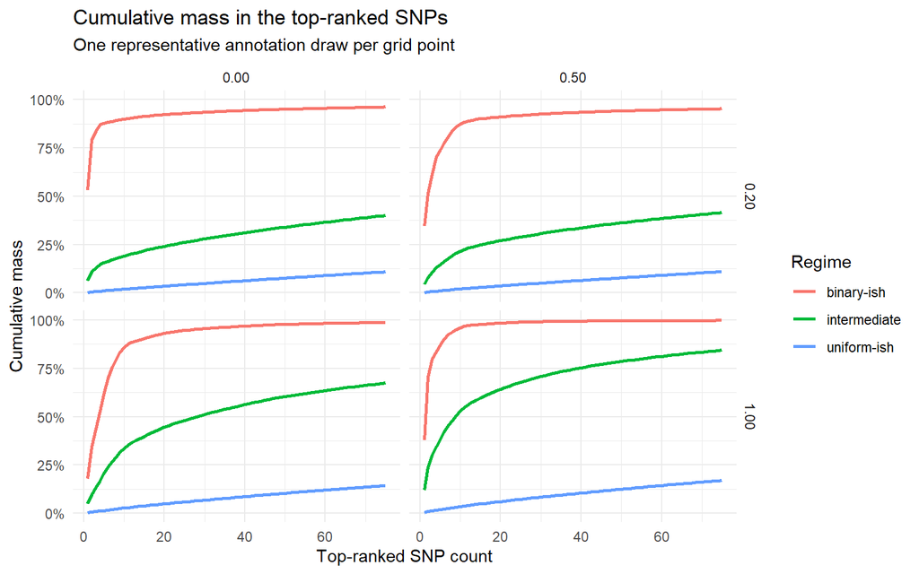

```r
ggplot(
  dplyr::filter(rank_curve_tbl, .data$rank <= 75),
  aes(x = .data$rank, y = .data$cumulative_mass, color = .data$regime)
) +
  geom_line(linewidth = 0.9) +
  facet_grid(.data$inflate_match_f ~ .data$annotation_r2_f) +
  scale_y_continuous(labels = scales::percent_format(accuracy = 1)) +
  labs(
    title = "Cumulative mass in the top-ranked SNPs",
    subtitle = "One representative annotation draw per grid point",
    x = "Top-ranked SNP count",
    y = "Cumulative mass",
    color = "Regime"
  ) +
  theme_minimal(base_size = 11)
```

# 11 A Single-Draw View in Annotation Space

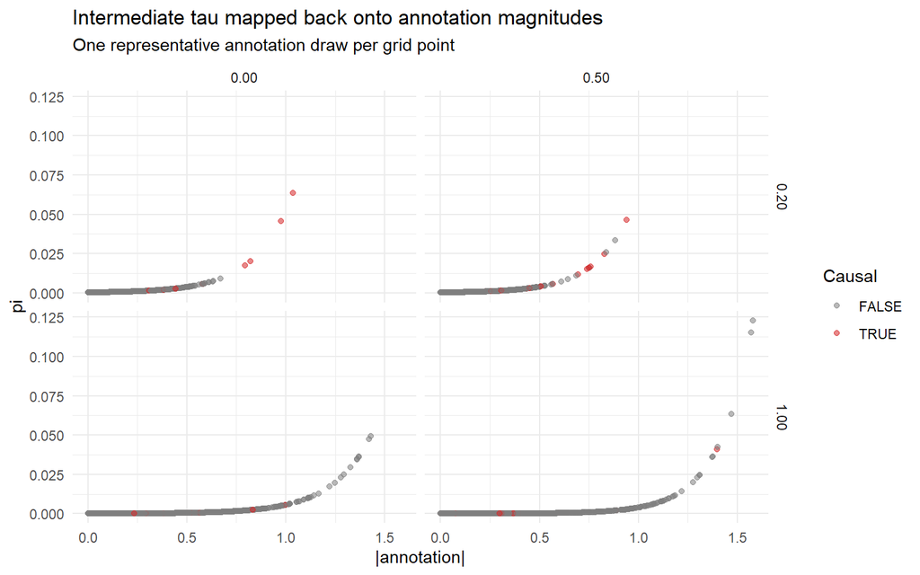

```r
intermediate_tau_tbl <- selected_reference_tau %>%
  dplyr::filter(.data$regime == "intermediate") %>%
  dplyr::left_join(
    representative_rows %>%
      dplyr::select(
        .data$setting_id,
        .data$beta,
        .data$annotation,
        .data$causal_idx,
        .data$annotation_r2_f,
        .data$inflate_match_f
      ),
    by = c("setting_id", "annotation_r2_f", "inflate_match_f")
  ) %>%
  dplyr::mutate(
    plot_tbl = purrr::pmap(
      list(.data$beta, .data$annotation, .data$tau),
      function(beta, annotation, tau) {
        pi_vec <- softmax_pi_from_annotation(
          annotation = annotation,
          tau = tau,
          eta = eta_uniform
        )$pi
        tibble::tibble(
          snp = seq_along(annotation),
          beta = beta,
          annotation = annotation,
          pi = pi_vec
        )
      }
    )
  ) %>%
  dplyr::select(
    .data$annotation_r2_f,
    .data$inflate_match_f,
    .data$causal_idx,
    .data$plot_tbl
  ) %>%
  tidyr::unnest(.data$plot_tbl) %>%
  dplyr::mutate(
    causal = purrr::map2_lgl(.data$snp, .data$causal_idx, ~ .x %in% .y)
  )

ggplot(intermediate_tau_tbl, aes(x = abs(.data$annotation), y = .data$pi, color = .data$causal)) +
  geom_point(alpha = 0.55) +
  facet_grid(.data$inflate_match_f ~ .data$annotation_r2_f) +
  scale_color_manual(values = c("FALSE" = "#7f7f7f", "TRUE" = "#d62728")) +
  scale_y_continuous(labels = scales::label_number(accuracy = 0.001)) +
  labs(
    title = "Intermediate tau mapped back onto annotation magnitudes",
    subtitle = "One representative annotation draw per grid point",
    x = "|annotation|",
    y = "pi",
    color = "Causal"
  ) +
  theme_minimal(base_size = 11)
```

# 12 Notes

- This workbook now matches the fixed `susie2_oligogenic` architecture exactly. The causal architecture is 3 sparse + 5 oligogenic + 15 polygenic variants, so `p_star` is intentionally absent.
- The annotation transform is normalized by a robust scale estimate of `|a|`, so `tau` is dimensionless.
- For `p = 1000`, the uniform baseline is `0.001` per SNP. The counts `n_gt_5x_uniform` and `n_gt_10x_uniform` are stored in `tau_results` if you want to inspect how many variants are materially favored at each `tau`.
- If this workbook points to a narrow stable `tau` window across the grid, that window can be promoted into a formal `tau_grid_values` proposal in the run-control layer.